# EDA_FE

## 1.8 Analysing sc - Serum Creatinine

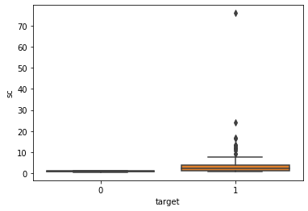

```python
sns.boxplot('target','sc',data = X_train_df)
```

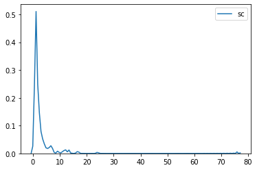

```python
sns.kdeplot(X_train_df['sc'])
```

The distribution is right skewed and contains outliers.

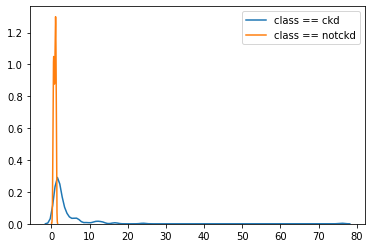

```python
sns.kdeplot(X_train_df.loc[X_train_df['classification'] == 'ckd','sc'], label = 'class == ckd')
sns.kdeplot(X_train_df.loc[X_train_df['classification'] == 'notckd','sc'], label = 'class == notckd')
```

Normal creatinine levels are in the range of 0.5 to 1.2 mg/dL  
As can be seen from the plot above, those in the normal range have less chances of ckd as compared to those beyond the normal range.

```python
qSc = np.percentile(X_train_df.loc[X_train_df['classification'] == 'notckd','sc'],q=[75,90,99])
qSc
```

```
array([1.1, 1.2, 1.3])
```

Even the quantile values suggest the same.  
Let's form binary bins with 0 for normal range of blood creatinine values and 1 for values beyond the normal range.

```python
feature_df['sc_bin'] = X_train_df['sc'].apply(lambda x : 0 if x <= 1.2 else 1)
```

```python
feature_df[['sc_bin','target']].corr()['target']
```

```
sc_bin    0.751925
target    1.000000
Name: target, dtype: float64
```

```python
X_train_df[['sc','target']].corr()['target']
```

```
sc        0.258217
target    1.000000
Name: target, dtype: float64
```

Correlation value has been increased from 0.25 to 0.75

## Let's try to normalize this right skewed feature

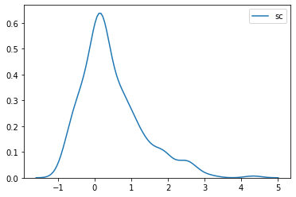

```python
log_norm = np.log(X_train_df['sc'])
sns.kdeplot(log_norm)
```

```python
feature_df['log_norm_sc'] = log_norm
```

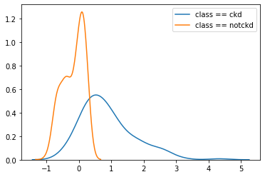

```python
sns.kdeplot(feature_df.loc[feature_df['target'] == 1,'log_norm_sc'], label = 'class == ckd')
sns.kdeplot(feature_df.loc[feature_df['target'] == 0,'log_norm_sc'], label = 'class == notckd')
```

Let us keep it like this.  
Not forming any binary feature since we already have built them earlier.

```python
feature_df[['log_norm_sc','target']].corr()
```

|  | log_norm_sc | target |
| --- | --- | --- |
| log_norm_sc | 1.000000 | 0.605407 |
| target | 0.605407 | 1.000000 |

## 1.9 Analysing sod - Sodium

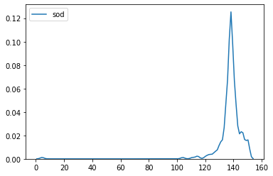

```python
sns.kdeplot(X_train_df['sod'])
```

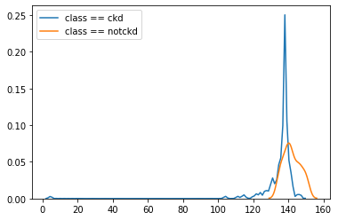

```python
sns.kdeplot(X_train_df.loc[X_train_df['classification'] == 'ckd','sod'], label = 'class == ckd')
sns.kdeplot(X_train_df.loc[X_train_df['classification'] == 'notckd','sod'], label = 'class == notckd')
```

```python
qSod = np.percentile(X_train_df.loc[X_train_df['classification'] == 'notckd','sod'],q=[0,25,50,75,99])
qSod
```

```
array([135., 138., 141., 146., 150.])
```

```python
qSod = np.percentile(X_train_df.loc[X_train_df['classification'] == 'ckd','sod'],q=[0,25,50,75,99])
qSod
```

```
array([  4.5 , 135.  , 138.  , 138.  , 145.44])
```

Normal range of Sodium lies in between 135-145 mEq/L  
Let's create binary feature.

```python
feature_df['sod_bin'] = X_train_df['sod'].apply(lambda x : 1 if x <= 138 else 0)
feature_df[['sod_bin','target']].corr()
```

|  | sod_bin | target |
| --- | --- | --- |
| sod_bin | 1.00000 | 0.54975 |
| target | 0.54975 | 1.00000 |

```python
X_train_df[['sod','target']].corr()
```

|  | sod | target |
| --- | --- | --- |
| sod | 1.000000 | -0.322329 |
| target | -0.322329 | 1.000000 |

Correlation value has increased from 0.32 to 0.54

## Let's normalize this feature

- let's see if we can improve correlation with target variable

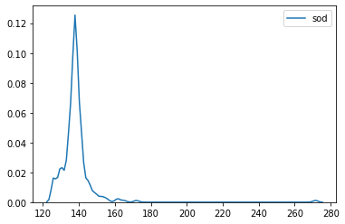

```python
median_sod = np.median(X_train_df['sod'])

def reflector(x):
  if x < median_sod:
    dev = median_sod-x
    return median_sod + dev
  elif x > median_sod:
    dev = x - median_sod
    return median_sod - dev
  else:
    return x
reflected_sod = X_train_df['sod'].apply(lambda x : reflector(x))
sns.kdeplot(reflected_sod)
```

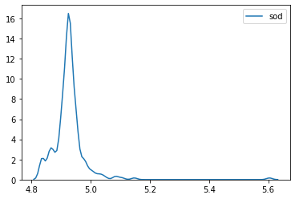

```python
## Converting this rightskewed distribution to normal distribution
log_norm_sod = np.log(reflected_sod)
sns.kdeplot(log_norm_sod)
```

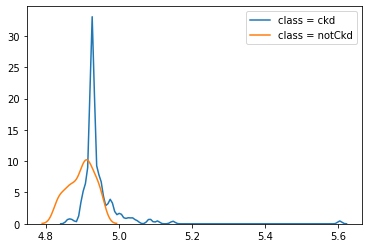

```python
feature_df['log_norm_sod'] = log_norm_sod
sns.kdeplot(feature_df.loc[feature_df['target'] == 1,'log_norm_sod'],label="class = ckd")
sns.kdeplot(feature_df.loc[feature_df['target'] == 0,'log_norm_sod'],label="class = notCkd")
```

```python
feature_df[['target','log_norm_sod']].corr()
```

|  | target | log_norm_sod |
| --- | --- | --- |
| target | 1.00000 | 0.38379 |
| log_norm_sod | 0.38379 | 1.00000 |

```python
qLogNormSodNCkd = np.percentile(feature_df[feature_df['target'] == 0]['log_norm_sod'],q=[0,25,50,75,99])
qLogNormSodCkd = np.percentile(feature_df[feature_df['target'] == 1]['log_norm_sod'],q=[0,25,50,75,99])

print(qLogNormSodNCkd)
print(qLogNormSodCkd)
```

```
[4.83628191 4.86753445 4.90527478 4.92725369 4.94875989]
[4.8598124  4.92725369 4.92725369 4.94875989 5.12422704]
```

75th percentile value for NCkd is same as 25th percentile value for CKD.  
We'll use this mark as a boundary for creating our binary bins

```python
feature_df['norm_sod_bin'] = feature_df['log_norm_sod'].apply(lambda x : 0 if x <= 4.92 else 1)
feature_df[['target','norm_sod_bin']].corr()
```

|  | target | norm_sod_bin |
| --- | --- | --- |
| target | 1.00000 | 0.54975 |
| norm_sod_bin | 0.54975 | 1.00000 |

The correlation value still remains the same.  
There was no point building this feature.

## 1.10 Analysing pot - Potassium

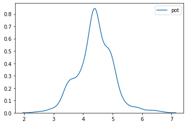

```python
sns.kdeplot(X_train_df['pot'])
```

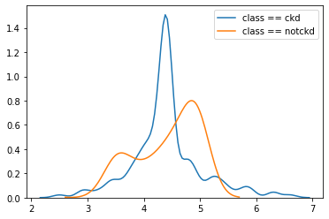

```python
sns.kdeplot(X_train_df.loc[X_train_df['classification'] == 'ckd','pot'], label = 'class == ckd')
sns.kdeplot(X_train_df.loc[X_train_df['classification'] == 'notckd','pot'], label = 'class == notckd')
```

```python
X_train_df[['target','pot']].corr()
```

|  | target | pot |
| --- | --- | --- |
| target | 1.000000 | -0.010682 |
| pot | -0.010682 | 1.000000 |

I don't think we can do much with this attribute.

## 1.11 Analysing hemo - Hemoglobin

```python
X_train_df[['target','hemo']].corr()
```

|  | target | hemo |
| --- | --- | --- |
| target | 1.00000 | -0.73239 |
| hemo | -0.73239 | 1.00000 |

Hemoglobin shows negative correlation

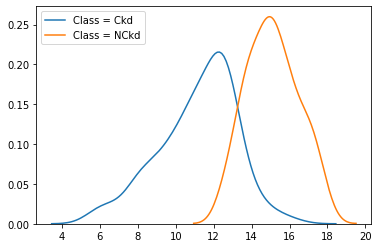

```python
sns.kdeplot(X_train_df.loc[X_train_df['target'] == 1,'hemo'],label = "Class = Ckd")
sns.kdeplot(X_train_df.loc[X_train_df['target'] == 0,'hemo'],label = "Class = NCkd")
```

```python
qPotNCkd = np.percentile(X_train_df[X_train_df['target'] == 1]['hemo'],q=[0,25,50,75,99])
qPotCkd = np.percentile(X_train_df[X_train_df['target'] == 0]['hemo'],q=[0,25,50,75,99])

print(qPotNCkd)
print(qPotCkd)
```

```
[ 5.8    9.8   11.4   12.65  15.264]
[12.65 14.   15.   16.05 17.8 ]
```

```python
feature_df['hemo_bin'] = X_train_df['hemo'].apply(lambda x : 0 if x <= 12.65 else 1)
feature_df[['target','hemo_bin']].corr()
```

|  | target | hemo_bin |
| --- | --- | --- |
| target | 1.000000 | -0.798655 |
| hemo_bin | -0.798655 | 1.000000 |

Forming bins has increased the correlation.  
Also By forming bins we are trying to generalize to some extent.

## 1.12 Analysing RC

```python
X_train_df[['target','rc']].corr()
```

|  | target | rc |
| --- | --- | --- |
| target | 1.00000 | -0.73315 |
| rc | -0.73315 | 1.00000 |

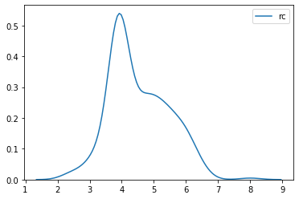

```python
sns.kdeplot(X_train_df['rc'])
```

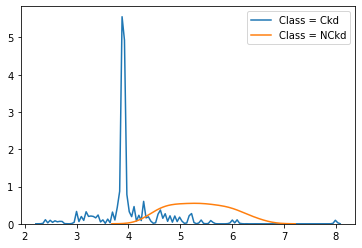

```python
sns.kdeplot(X_train_df.loc[X_train_df['target'] == 1,'rc'],label = "Class = Ckd")
sns.kdeplot(X_train_df.loc[X_train_df['target'] == 0,'rc'],label = "Class = NCkd")
```

```python
qRcNCkd = np.percentile(X_train_df[X_train_df['target'] == 1]['rc'],q=[0,25,50,75,99])
qRcCkd = np.percentile(X_train_df[X_train_df['target'] == 0]['rc'],q=[0,25,50,75,99])

print(qRcNCkd)
print(qRcCkd)
```

```
[2.3   3.9   3.9   4.    6.044]
[4.4 4.9 5.3 5.8 6.5]
```

```python
feature_df['rc_bin'] = X_train_df['rc'].apply(lambda x : 0 if x <= 4.4 else 1)
feature_df[['target','rc_bin']].corr()
```

|  | target | rc_bin |
| --- | --- | --- |
| target | 1.000000 | -0.822702 |
| rc_bin | -0.822702 | 1.000000 |

4.4 seems to be a good split point

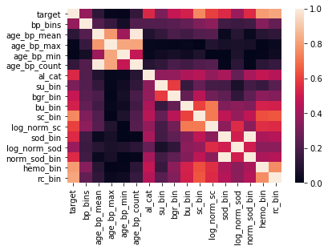

```python
sns.heatmap(abs(feature_df.corr()))
```

## 1.13 Analysing WC(White Blood Cell count)

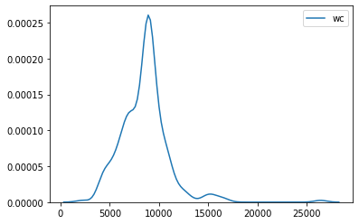

```python
sns.kdeplot(X_train_df['wc'])
```

```python
X_train_df[['wc','target']].corr()
```

|  | wc | target |
| --- | --- | --- |
| wc | 1.000000 | 0.279009 |
| target | 0.279009 | 1.000000 |

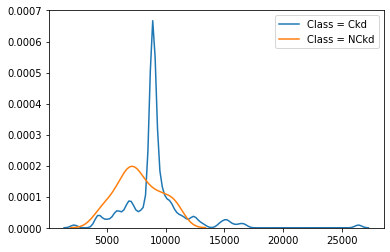

```python
sns.kdeplot(X_train_df.loc[X_train_df['target'] == 1,'wc'],label = "Class = Ckd")
sns.kdeplot(X_train_df.loc[X_train_df['target'] == 0,'wc'],label = "Class = NCkd")
```

```python
 qWcNCkd = np.percentile(X_train_df[X_train_df['target'] == 1]['wc'],q=[0,25,50,75,99])
qWcCkd = np.percentile(X_train_df[X_train_df['target'] == 0]['wc'],q=[0,25,50,75,99])
print(qWcNCkd)
print(qWcCkd)
```

```
[ 2200.  8600.  8900.  9600. 16476.]
[ 4300.  6350.  7500.  9200. 11000.]
```

```python
feature_df['wc_bin'] = X_train_df['wc'].apply(lambda x : 0 if x <=8600 else 1)
feature_df[['target','wc_bin']].corr()
```

|  | target | wc_bin |
| --- | --- | --- |
| target | 1.000000 | 0.444954 |
| wc_bin | 0.444954 | 1.000000 |

## Dropping GroupBy features

```python
feature_df.head()
```

|  | target | age_bins | bp_bins | age_bp_mean | age_bp_max | age_bp_min | age_bp_count | al_cat | su_bin | bgr_bin | bu_bin | sc_bin | log_norm_sc | sod_bin | log_norm_sod | norm_sod_bin | hemo_bin | rc_bin | wc_bin |
| --- | --- | --- | --- | --- | --- | --- | --- | --- | --- | --- | --- | --- | --- | --- | --- | --- | --- | --- | --- |
| 179 | 1 | 3 | 2 | 76.470588 | 100.0 | 60.0 | 85.0 | 1 | 0 | 0 | 1 | 1 | 0.832909 | 1 | 4.927254 | 1 | 0 | 0 | 1 |
| 270 | 0 | 1 | 1 | 72.790698 | 100.0 | 60.0 | 43.0 | 0 | 0 | 0 | 0 | 0 | 0.095310 | 0 | 4.875197 | 0 | 1 | 1 | 0 |
| 323 | 0 | 2 | 1 | 78.750000 | 180.0 | 50.0 | 112.0 | 0 | 0 | 0 | 0 | 0 | 0.095310 | 0 | 4.890349 | 0 | 1 | 1 | 0 |
| 399 | 0 | 2 | 1 | 78.750000 | 180.0 | 50.0 | 112.0 | 0 | 0 | 0 | 0 | 0 | 0.095310 | 0 | 4.905275 | 0 | 1 | 1 | 0 |
| 40 | 1 | 2 | 2 | 78.750000 | 180.0 | 50.0 | 112.0 | 1 | 0 | 0 | 1 | 1 | 0.741937 | 1 | 4.927254 | 1 | 0 | 0 | 1 |

Heatmap suggests that groupby features formed by age and bp are practically of no use.  
So we'll drop this features.

```python
feature_df.drop(['age_bp_mean','age_bp_max','age_bp_min','age_bp_count'],axis = 1,inplace = True)
feature_df.head(4)
```

|  | target | age_bins | bp_bins | al_cat | su_bin | bgr_bin | bu_bin | sc_bin | log_norm_sc | sod_bin | log_norm_sod | norm_sod_bin | hemo_bin | rc_bin | wc_bin |
| --- | --- | --- | --- | --- | --- | --- | --- | --- | --- | --- | --- | --- | --- | --- | --- |
| 179 | 1 | 3 | 2 | 1 | 0 | 0 | 1 | 1 | 0.832909 | 1 | 4.927254 | 1 | 0 | 0 | 1 |
| 270 | 0 | 1 | 1 | 0 | 0 | 0 | 0 | 0 | 0.095310 | 0 | 4.875197 | 0 | 1 | 1 | 0 |
| 323 | 0 | 2 | 1 | 0 | 0 | 0 | 0 | 0 | 0.095310 | 0 | 4.890349 | 0 | 1 | 1 | 0 |
| 399 | 0 | 2 | 1 | 0 | 0 | 0 | 0 | 0 | 0.095310 | 0 | 4.905275 | 0 | 1 | 1 | 0 |

```python
print("Number of newly discovered features with Univariate Analysis : ",len(feature_df.columns)-1)
```

```
Number of newly discovered features with Univariate Analysis :  14
```

## Multivariate Feature Analysis

```python
numeric_df = X_train_df.select_dtypes(include=['int64','float64'])
```

Since the number of features is more and pairplots will form a big grid of scatter plot's and kde which will be difficult to look at.  
Let's see which attributes should be seen together to get some idea about feature interaction.

```python
numeric_df.columns
```

```
Index(['id', 'age', 'bp', 'sg', 'al', 'su', 'rbc', 'pc', 'bgr', 'bu', 'sc',
       'sod', 'pot', 'hemo', 'rc', 'target'],
      dtype='object')
```

```python
cat_df = X_train_df.select_dtypes(include=['object'])
cat_df.columns
```

```
Index(['pcc', 'ba', 'htn', 'dm', 'cad', 'appet', 'pe', 'ane',
       'classification'],
      dtype='object')
```

It has been observed that there is certain permissible level of sc(serum creatinine) and bu(blood urea) beyond which there are chances of a person contracting chronic kidney disease.  
https://www.kidney.org/atoz/content/kidneytests

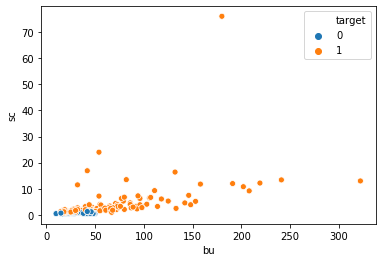

```python
sns.scatterplot(x = 'bu',y='sc',hue='target',data=X_train_df)
```

Looking at the simple scatter plot we can form a simple binary feature.

```python
def sc_bu_bin(x):
    if x['sc'] <= 1.4 and x['bu'] <= 50:
        return 0
    else:
        return 1
feature_df['sc_bu_bin'] = X_train_df.apply(lambda x : sc_bu_bin(x),axis = 1)
feature_df[['sc_bu_bin','target']].corr()
```

|  | sc_bu_bin | target |
| --- | --- | --- |
| sc_bu_bin | 1.000000 | 0.694777 |
| target | 0.694777 | 1.000000 |

```python
feature_df.head()
```

|  | target | age_bins | bp_bins | al_cat | su_bin | bgr_bin | bu_bin | sc_bin | log_norm_sc | sod_bin | log_norm_sod | norm_sod_bin | hemo_bin | rc_bin | wc_bin | sc_bu_bin |
| --- | --- | --- | --- | --- | --- | --- | --- | --- | --- | --- | --- | --- | --- | --- | --- | --- |
| 179 | 1 | 3 | 2 | 1 | 0 | 0 | 1 | 1 | 0.832909 | 1 | 4.927254 | 1 | 0 | 0 | 1 | 1 |
| 270 | 0 | 1 | 1 | 0 | 0 | 0 | 0 | 0 | 0.095310 | 0 | 4.875197 | 0 | 1 | 1 | 0 | 0 |
| 323 | 0 | 2 | 1 | 0 | 0 | 0 | 0 | 0 | 0.095310 | 0 | 4.890349 | 0 | 1 | 1 | 0 | 0 |
| 399 | 0 | 2 | 1 | 0 | 0 | 0 | 0 | 0 | 0.095310 | 0 | 4.905275 | 0 | 1 | 1 | 0 | 0 |
| 40 | 1 | 2 | 2 | 1 | 0 | 0 | 1 | 1 | 0.741937 | 1 | 4.927254 | 1 | 0 | 0 | 1 | 1 |

```python
feature_df['acr'] = X_train_df['al']/X_train_df['sc']
feature_df[['acr','target']].corr()
```

|  | acr | target |
| --- | --- | --- |
| acr | 1.000000 | 0.417466 |
| target | 0.417466 | 1.000000 |

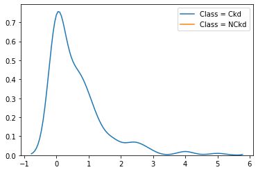

```python
sns.kdeplot(feature_df.loc[feature_df['target'] == 1,'acr'],label = "Class = Ckd")
sns.kdeplot(feature_df.loc[feature_df['target'] == 0,'acr'],label = "Class = NCkd")
```

Since we know Albumin,Creatinine and Blood Urea are important in deciding CKD.  
Let's form Polynomial features and see if we can get anything.

```python
from sklearn.preprocessing import PolynomialFeatures
polyFeatures = PolynomialFeatures(2)
imp_feat_df = polyFeatures.fit_transform(X_train_df[['sc','al','bu']])
```

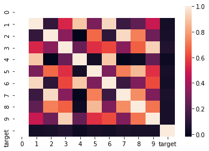

```python
impt_feat_df = pd.DataFrame(imp_feat_df)
impt_feat_df['target'] = feature_df['target']
sns.heatmap(impt_feat_df.corr())
```

All developed polynomial features have almost 0 correlation with target variable.

## Applying Box-Cox Transformations to continuous attributes

Let's apply Box-Cox tranform to all of the numeric features and get new normally distributed features.  
Take each of the sample from train data and get it's probability distribution function.  
I am talking about Multivariate_normal.pdf and see if we can build a binary feature.

Box-Cox Transformations take only positive data.  
So normalizing this data using min-max scaler.

```python
from sklearn.preprocessing import MinMaxScaler
numeric_x_df = numeric_df.drop(['id','target'],axis = 1)
numeric_y_df = numeric_df['target']

scaler = MinMaxScaler()
numeric_x_transformed = scaler.fit_transform(numeric_x_df)
numeric_x_trans_df = pd.DataFrame(numeric_x_transformed,columns = numeric_x_df.columns)
```

```python
from scipy.stats import boxcox

# Forming a dataFrame to contain box-cox transformedd variables
box_cox_df = pd.DataFrame()

#Transforming all numeric columns except id and target
for col in numeric_x_trans_df.columns:
    if col != 'id' and col != 'target':
        box_cox_df['box_cox_' + col] = boxcox(numeric_x_trans_df[col]+1)[0]
```

```python
box_cox_df.columns
```

```
Index(['box_cox_age', 'box_cox_bp', 'box_cox_sg', 'box_cox_al', 'box_cox_su',
       'box_cox_rbc', 'box_cox_pc', 'box_cox_bgr', 'box_cox_bu', 'box_cox_sc',
       'box_cox_sod', 'box_cox_pot', 'box_cox_hemo', 'box_cox_rc'],
      dtype='object')
```

```
box_cox_su
```

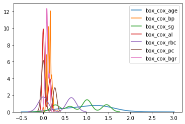

```python
for col in box_cox_df.columns[:8]:
    try:
        sns.kdeplot(box_cox_df[col])
    except:
        print(col)
```

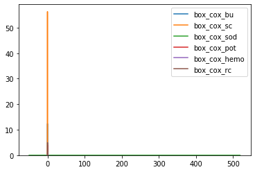

```python
for col in box_cox_df.columns[8:]:
    try:
        sns.kdeplot(box_cox_df[col])
    except:
        print(col)
```

The Distributions are decently normal.  
Actually they aren't! Hahaha!

```python
from sklearn.preprocessing import  StandardScaler

scaler  = StandardScaler().fit(box_cox_df)
box_cox_std = scaler.transform(box_cox_df)

## Let's calculate covariance and mean for multivariate analysis
sigma = np.cov(box_cox_std.T)
print("Shape of Covariance matrix : ",sigma.shape)
mean = np.mean(box_cox_std,axis = 0)
print("Mean of box cox_df : ",mean)
```

```
Shape of Covariance matrix :  (14, 14)
Mean of box cox_df :  [-3.78169718e-16 -4.85722573e-17  3.33066907e-16  5.89805982e-17
  6.24500451e-17 -6.93889390e-18  9.02056208e-17  1.80411242e-16
  1.42247325e-16  1.17961196e-16  7.60676244e-16 -1.63064007e-16
 -2.35922393e-16 -4.44089210e-16]
```

## Calculating multivariate normal pdf

```python
from scipy.stats import multivariate_normal
multivariate_pdf = multivariate_normal.pdf(box_cox_std,mean=mean,cov=sigma)
feature_df['multivariate_pdf'] = multivariate_pdf
feature_df['log_multivariate_pdf'] = np.log(multivariate_pdf)
```

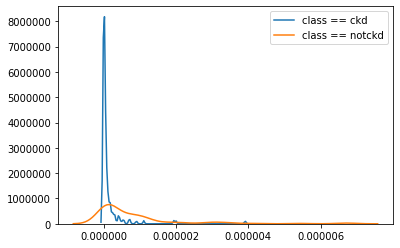

```python
sns.kdeplot(feature_df.loc[feature_df['target'] == 1,'multivariate_pdf'], label = 'class == ckd')
sns.kdeplot(feature_df.loc[feature_df['target'] == 0,'multivariate_pdf'], label = 'class == notckd')
```

```python
feature_df[['multivariate_pdf','target']].corr()
```

|  | multivariate_pdf | target |
| --- | --- | --- |
| multivariate_pdf | 1.000000 | -0.374873 |
| target | -0.374873 | 1.000000 |

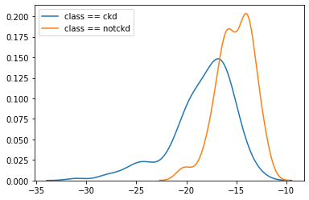

```python
sns.kdeplot(feature_df.loc[feature_df['target'] == 1,'log_multivariate_pdf'], label = 'class == ckd')
sns.kdeplot(feature_df.loc[feature_df['target'] == 0,'log_multivariate_pdf'], label = 'class == notckd')
```

```python
feature_df[['log_multivariate_pdf','target']].corr()
```

|  | log_multivariate_pdf | target |
| --- | --- | --- |
| log_multivariate_pdf | 1.000000 | -0.500745 |
| target | -0.500745 | 1.000000 |

## Let's try to form a binary feature using the above pdf

```python
qLogMultiPdfNCkd = np.percentile(feature_df[feature_df['target'] == 0]['log_multivariate_pdf'],q=[0,25,50,75,99])
qLogMultiPdfCkd = np.percentile(feature_df[feature_df['target'] == 1]['log_multivariate_pdf'],q=[0,25,50,75,99])

print(qLogMultiPdfCkd)
print(qLogMultiPdfNCkd)
```

```
[-30.98424697 -19.74149681 -17.73784374 -16.24877048 -13.13937376]
[-20.4805743  -16.15454415 -15.00272175 -13.82512002 -11.91900243]
```

```python
feature_df['log_multi_pdf_bin'] = feature_df['log_multivariate_pdf'].apply(lambda x : 1 if x <= -16.24 else 0)
feature_df[['target','log_multi_pdf_bin']].corr()
```

|  | target | log_multi_pdf_bin |
| --- | --- | --- |
| target | 1.000000 | 0.517886 |
| log_multi_pdf_bin | 0.517886 | 1.000000 |

Doesn't seem to be that useful.  
But let's keep it.

```python
feature_df.columns
```

```
Index(['target', 'age_bins', 'bp_bins', 'al_cat', 'su_bin', 'bgr_bin',
       'bu_bin', 'sc_bin', 'log_norm_sc', 'sod_bin', 'log_norm_sod',
       'norm_sod_bin', 'hemo_bin', 'rc_bin', 'wc_bin', 'sc_bu_bin', 'acr',
       'multivariate_pdf', 'log_multivariate_pdf', 'log_multi_pdf_bin'],
      dtype='object')
```

## Let's dump the generated features for future use

```python
sampleFile = open('feature_df','wb')
pickle.dump(feature_df,sampleFile)
sampleFile.close()
```

```python
feature_df.shape
```

```
(256, 20)
```